# Notebook

Bayesian Paper Figures  
Web Links:

1. Latest draft ➡ [Felikson et al, 2024](https://docs.google.com/document/d/12eSfhWnAeoUkK7Thtg2Uu3TRNPoc01nZvtP-wd8_gMo/edit)
2. Google Drive [(LINK)](https://drive.google.com/drive/u/1/folders/1-TLNuYqtY_WAgig2PP9dFavE7MPFToIU)
3. OLD: Outline and group paper:[draft](https://docs.google.com/document/d/12m-c9fadnrJwwsSBS3rPiVQBRuusdT6O-bqZ-HCNwsU/edit)
4. Synopsis framework for Nature Reviews Earth & Environment: [link](https://docs.google.com/document/d/12eSfhWnAeoUkK7Thtg2Uu3TRNPoc01nZvtP-wd8_gMo/edit)
5. PK/Bob section on Total sea level [googleDoc](https://docs.google.com/document/d/1f2_aIJQ9_wR_prMBrcS7PoP4TXC4e97Uiikg8Rs_8xA/edit)

**To substantiate from figure**

1. deep uncertainty:: produce a version of the figure for wf4.
2. we are better off focusing on the individual components, *as opposed to comparing tide gauge data to projections*

FACTS produces Total SL projections ,  
calculated by aggregating component probability distributions into probability distributions for total GMSL and RSL change

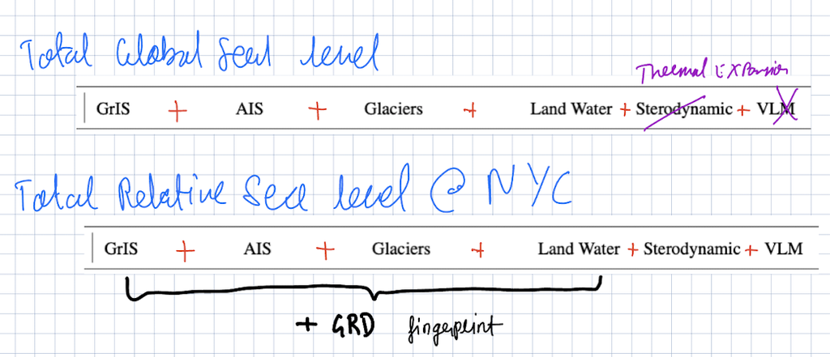

```
<IPython.core.display.Image object>
```

Also check  
[Regional Relative Sea-Level Change](https://sealevel.nasa.gov/understanding-sea-level/regional-sea-level/overview/)

[figure not shown]

```
<IPython.core.display.Image object>
```

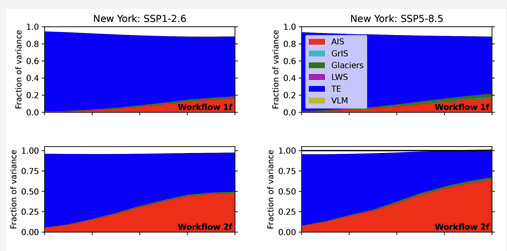

```
<IPython.core.display.Image object>
```

Background

FACTS workflow description

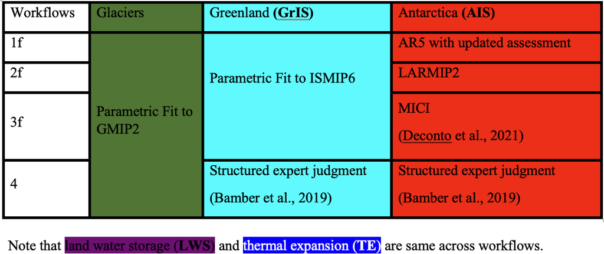

```
<IPython.core.display.Image object>
```

Import Modules necessary for running this notebook

LIST :: FACTS 1.1.1 run datasets

```
 Index                                                          File Name
     0            coupling.ssp245.GrIS1f.FittedISMIP.GrIS_GIS_globalsl.nc
     1           coupling.ssp245.ar5AIS.ipccar5.icesheets_AIS_globalsl.nc
     2          coupling.ssp245.ar5AIS.ipccar5.icesheets_EAIS_globalsl.nc
     3           coupling.ssp245.ar5AIS.ipccar5.icesheets_GIS_globalsl.nc
     4          coupling.ssp245.ar5AIS.ipccar5.icesheets_WAIS_globalsl.nc
     5           coupling.ssp245.ar5glaciers.ipccar5.glaciers_globalsl.nc
     6        coupling.ssp245.bamber19.bamber19.icesheets_AIS_globalsl.nc
     7       coupling.ssp245.bamber19.bamber19.icesheets_EAIS_globalsl.nc
     8        coupling.ssp245.bamber19.bamber19.icesheets_GIS_globalsl.nc
     9       coupling.ssp245.bamber19.bamber19.icesheets_WAIS_globalsl.nc
    10            coupling.ssp245.deconto21.deconto21.AIS_AIS_globalsl.nc
    11           coupling.ssp245.deconto21.deconto21.AIS_EAIS_globalsl.nc
    12           coupling.ssp245.deconto21.deconto21.AIS_WAIS_globalsl.nc
    13             coupling.ssp245.emuAIS.emulandice.AIS_EAIS_globalsl.nc
    14              coupling.ssp245.emuAIS.emulandice.AIS_PEN_globalsl.nc
    15             coupling.ssp245.emuAIS.emulandice.AIS_WAIS_globalsl.nc
    16                  coupling.ssp245.emuAIS.emulandice.AIS_globalsl.nc
    17                coupling.ssp245.emuGrIS.emulandice.GrIS_globalsl.nc
    18 coupling.ssp245.emuglaciers.emulandice.glaciers_glac10_globalsl.nc
    19 coupling.ssp245.emuglaciers.emulandice.glaciers_glac11_globalsl.nc
    20 coupling.ssp245.emuglaciers.emulandice.glaciers_glac12_globalsl.nc
    21 coupling.ssp245.emuglaciers.emulandice.glaciers_glac13_globalsl.nc
    22 coupling.ssp245.emuglaciers.emulandice.glaciers_glac14_globalsl.nc
    23 coupling.ssp245.emuglaciers.emulandice.glaciers_glac15_globalsl.nc
    24 coupling.ssp245.emuglaciers.emulandice.glaciers_glac16_globalsl.nc
    25 coupling.ssp245.emuglaciers.emulandice.glaciers_glac17_globalsl.nc
    26 coupling.ssp245.emuglaciers.emulandice.glaciers_glac18_globalsl.nc
    27 coupling.ssp245.emuglaciers.emulandice.glaciers_glac19_globalsl.nc
    28  coupling.ssp245.emuglaciers.emulandice.glaciers_glac1_globalsl.nc
    29  coupling.ssp245.emuglaciers.emulandice.glaciers_glac2_globalsl.nc
    30  coupling.ssp245.emuglaciers.emulandice.glaciers_glac3_globalsl.nc
    31  coupling.ssp245.emuglaciers.emulandice.glaciers_glac4_globalsl.nc
    32  coupling.ssp245.emuglaciers.emulandice.glaciers_glac5_globalsl.nc
    33  coupling.ssp245.emuglaciers.emulandice.glaciers_glac6_globalsl.nc
    34  coupling.ssp245.emuglaciers.emulandice.glaciers_glac7_globalsl.nc
    35  coupling.ssp245.emuglaciers.emulandice.glaciers_glac8_globalsl.nc
    36  coupling.ssp245.emuglaciers.emulandice.glaciers_glac9_globalsl.nc
    37        coupling.ssp245.emuglaciers.emulandice.glaciers_globalsl.nc
    38                 coupling.ssp245.larmip.larmip.AIS_EAIS_globalsl.nc
    39                  coupling.ssp245.larmip.larmip.AIS_PEN_globalsl.nc
    40                  coupling.ssp245.larmip.larmip.AIS_SMB_globalsl.nc
    41                 coupling.ssp245.larmip.larmip.AIS_WAIS_globalsl.nc
    42                      coupling.ssp245.larmip.larmip.AIS_globalsl.nc
    43               coupling.ssp245.lws.ssp.landwaterstorage_globalsl.nc
    44                coupling.ssp245.ocean.tlm.sterodynamics_globalsl.nc
    45                      coupling.ssp245.total.workflow.wf1e.global.nc
    46                      coupling.ssp245.total.workflow.wf1f.global.nc
    47                      coupling.ssp245.total.workflow.wf2e.global.nc
    48                      coupling.ssp245.total.workflow.wf2f.global.nc
    49                      coupling.ssp245.total.workflow.wf3e.global.nc
    50                      coupling.ssp245.total.workflow.wf3f.global.nc
    51                       coupling.ssp245.total.workflow.wf4.global.nc
```

Plot Params

Posterior NYC total SL Densities in 2100 conditional on

1. 2030 GMSL observations TOTAL
2. 2030 RSL observation TOTAL
3. 2030 Thermal Expansion
4. 2030 Sterodynamic observations
5. 2030 AIS component

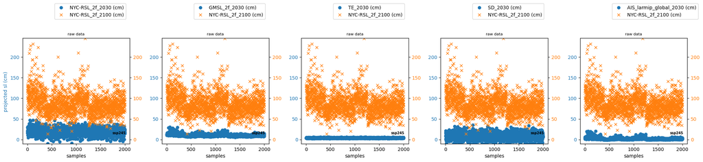

```
<Figure size 2500x400 with 10 Axes>
```

[figure not shown]

```
<Figure size 1000x1000 with 5 Axes>
```

SCRATCH

2050/2100 NYC projections conditional on GMSL contribution of AIS Component

1. 2030 AR5
2. 2030 larmip
3. 2030 d21
4. 2030 b19

TOTAL GMSL (WF) projections conditional on AIS Component

1. 2030 AIS ar5 **global**
2. 2030 AIS larmp **global**
3. 2030 AIS d21 **global**
4. 2030 AIS b19 **global**

TOTAL NYC-WF-SL projections conditional on TOTAL GLOBAL

1. 2030 GMSL-WF (AR5)
2. 2030 GMSL-WF (larmip)
3. 2030 GMSL-WF (d21)
4. 2030 GMSL-WF (b19)